# Post-Earnings Price Reaction: A Statistical Analysis

**How do stocks move after earnings — and why?**

Every quarter, more than 500 S&P 500 companies report results. In the hours that follow, stocks can gap +20% on a blowout quarter or crater -15% on a miss. Understanding the statistical structure of these reactions — what drives them, what the market consistently gets right or wrong, and how much predictive signal actually exists — is the foundation of any systematic earnings strategy.

- Daily price data (via Yahoo Finance)
- Earnings results and surprise data (Financial Modeling Prep)
- Quarterly fundamental data (FMP)
- Macroeconomic indicators (FRED: VIX, yield curve, fed funds)
- SEC 8-K press releases parsed for guidance and management tone (13,773 filings)

The analysis proceeds in five parts:

1. **The distribution of earnings reactions** — how unusual, fat-tailed, and asymmetric price gaps actually are
2. **Factor analysis** — which variables statistically explain the magnitude and direction of the gap
3. **The priced-in effect** — how pre-earnings run-up diminishes post-earnings upside
4. **Post-earnings drift** — whether the initial gap predicts subsequent price movement
5. **Market regime** — how macro conditions shape reaction size

```
Total events : 15,777
Train        : 11,717  (2018-01-05 – 2023-12-31)
Val (2024)   : 1,994
Unique tickers: 502
```

## 1. The Distribution of Earnings Reactions

Before examining what causes earnings gaps, we need to understand their statistical character. A key question is whether earnings reactions follow a normal distribution — if they did, large moves would be extremely rare and the tails would be thin. In practice, financial returns — and earnings gaps in particular — are known to be fat-tailed (leptokurtic): extreme moves happen far more often than a normal distribution would predict.

We also examine asymmetry: does the market tend to punish misses more harshly than it rewards beats?

```
Earnings Reaction (ret_0d) — Summary Statistics

                    Value
Count            11717.00
Mean                0.18%
Median              0.18%
Std Dev             4.13%
Skewness             0.04
Excess Kurtosis      6.79
5th Percentile     -6.26%
25th Percentile    -1.71%
75th Percentile     2.06%
95th Percentile     6.54%
% moves > +10%      1.61%
% moves < -10%      1.33%
% moves > +5%       8.71%
% moves < -5%       7.72%
```

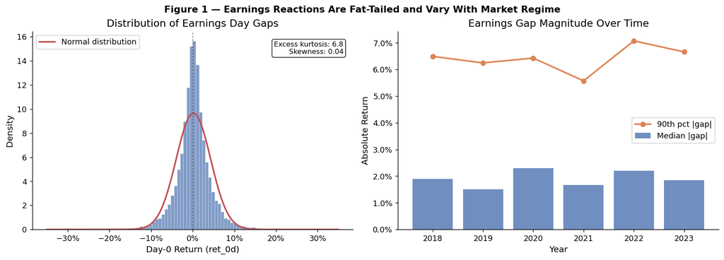

```
D'Agostino-Pearson normality test: statistic=1611.8, p=0.00e+00
→ Strong evidence against normality (fat tails confirmed)

Events with gap > +5%  : 1,021  (8.7%)
Events with gap < -5%  : 905  (7.7%)

Among large moves:
  Avg big beat   : +8.1%
  Avg big miss   : -8.1%
```